# Ticketing and Turnout: How Policing for Profit Shapes Democratic Participation

Jonathan Ben-Menachem[^1]

Kevin Morris[^2]

July 23, 2021

Abstract

**Keywords**: voting, monetary sanctions, race, punishment, political participation

https://journals.sagepub.com/author-instructions/ASR

Ticketing and Turnout: How Policing for Profit Shapes Democratic Participation

Corresponding author: Jonathan Ben-Menachem jbenmenachem@gmail.com 194 Bleecker St Apt C, New York, NY 10012 908-698-2223 (email preferred for initial contact)

Kevin Morris

Ticketing and Turnout: How Policing for Profit Shapes Democratic Participation

Jonathan Ben-Menachem, Columbia University, Department of Sociology Kevin Morris, CUNY Graduate Center, Department of Sociology

Keywords: voting, monetary sanctions, race, punishment, political participation

Corresponding author: Jonathan Ben-Menachem jbenmenachem@gmail.com 194 Bleecker St Apt C, New York, NY 10012 908-698-2223 (email preferred for initial contact)

# Introduction

Fines and fees are increasingly recognized as a form of racist revenue extraction connected to marginalized communities’ alienation from government [@Sanders2017; @McCoy2015; @Shaer2019]. After Michael Brown was killed by the Ferguson Police Department in 2014, a US Department of Justice investigation into the city’s police and courts demonstrated that the municipality was engaged in a practice that advocates now refer to as “policing for profit.” The city’s reliance on fines and fees to fund government functions grew from 13 to 23 percent of the total budget between fiscal years 2012 and 2015. From 2012 to 2014, the Department of Justice found that 85 percent of vehicle stops, 90 percent of citations, and 93 percent of arrests targeted Black people. By contrast, just two-thirds of Ferguson’s residents are Black [@UnitedStatesDepartmentofJusticeCivilRightsDivision2015].

It wasn’t just a Ferguson problem, or even a Missouri problem. American cities’ reliance on fines and fees revenue increased significantly following the 2008 recession—as local tax revenues dropped and tax increases became less politically viable, jurisdictions increased the amounts of fines and fees and imposed them more frequently in order to fund government services [@Singla2020; @Harris2017; @Harris2020].

Work exploring how criminalization directly and indirectly influences political participation has exploded in recent years following path-breaking work from political sociologists Chris Uggen and Jeff Manza [@Uggen2002; @Manza2006]. Scholars have found that criminal legal contact (i.e. arrest, conviction, incarceration) consistently discourages voting [@Weaver2010; @Burch2011; @White2019a]. Such work has largely focused on the effects of highly disruptive contact with the criminal legal system such as incarceration and felony convictions [@Burch2014; @Lee2014]. While ticketing involves potentially negative interactions with the state, it does not necessarily carry the disruptive consequences of a felony conviction and might thus politicize Americans in unique ways. Building on recent theoretical work from @Walker2020a and an analysis of the historical context of fees and fines collections in the United States, this paper is the first to explicitly theorize how local ticketing practices shape the political socialization of ticketed individuals. We argue that ticketing depresses voter turnout overall, but also catalyzes a “linked fate” political analysis among Black voters that either causes increased turnout or mitigates the turnout reductions observed among non-Black individuals.

Additionally, our project represents the first use of individual-level administrative data to identify the causal effect of ticketing on voter behavior. The use of administrative data marks an important step forward in our understanding of how low-level contact with the criminal legal system structures political participation. Past work looking at the individual-level effects of low-level contact has relied entirely on survey or qualitative data [e.g. @Walker2014; @Weaver2010]. Existing research allows for the testing of specific psychological mechanisms and personal interpretations of criminal legal contact, but does not allow us to generalize more broadly. As Weaver and Lerman [-@Weaver2010: 821] note, it may also introduce measurement bias. Our analysis investigates actual voting behavior following actual ticketing events, not reported voting behavior or reported exposure to police ticketing. The administrative data therefore allow us both to sidestep reporting error and to observe the behavior of a quarter-million individuals ticketed over a 6 year period—a far larger pool than even the most robust surveys.

We use individual-level traffic stop data from Hillsborough County, Florida, to identify the turnout patterns of voters who were ticketed between the 2012 and 2018 elections. By matching individual voters who were ticketed to similar voters who were ticketed at later points and running a difference-in-differences model, we estimate the causal effect of these tickets on turnout. We find that being ticketed reduces the chance that an individual will turn out in the subsequent election, but that this effect is smaller for Black voters.

To test the generalizability of our findings in Hillsborough County, we leverage two different datasets that are national in scope. First, we join fees and fines data from municipalities around the country in 2012 and 2017 with a novel dataset estimating racial turnout for thousands of municipalities around the country. While we find that increased fees and fines likely cause lower turnout among non-Black Americans, we find no effect of fees and fines on Black turnout.

Second, we conduct a novel analysis of 2020 national survey data regarding voters’ experience with police stops. We find that Black respondents who reported personal or proximal experience with police stops in the last 12 months are more likely to vote than Black people who did not, while we find no statistically significant relationship between stops and voting among non-Black respondents. While both the municipal-level and survey data present some drawbacks relative to the individual-level administrative data, their national scope provides helpful corroboration for the unique turnout effects of tickets for Black Americans observed in Hillsborough County.

We demonstrate that police ticketing practices—the most widespread form of police contact in America—substantially reduce the turnout of non-Black American voters, but can mobilize Black voters. Our findings complicate existing theories of how criminalization politically socializes Americans, and Black Americans in particular [@Weaver2010]. Additionally, while all forms of criminalization likely contribute to a subjective experience of alienation or group-level exclusion among Black Americans that is well-documented in sociological scholarship [@Bell2017; @Desmond2016], our contribution emphasizes the need for further research regarding how different forms of criminalization affect group-level perceptions of government and resultant political behaviors. Accordingly, we propose a new theory explaining how ticketing may uniquely catalyze Black political participation. Our findings are relevant for interdisciplinary scholars of crime, race, politics, political economy, social movements, and policing.

# Literature Review

An emerging political science literature directly investigates the relationship between criminalization and political behavior. Additionally, sociologists have incorporated contemporary fines and fees practices into a broader empirical-historical theory of racialized punishment policy [@Harris2010; @Friedman2020].

In order to theorize how fines and fees affect political behavior, we consider how criminalization directly shapes the electorate; the existing scholarly understanding of the influence of criminalization on political socialization; and how contemporary ticketing practices are tied to a longer legacy of racist exploitation and thus ripe for political mobilization around narratives of racial injustice.

## Criminalization and political socialization

The American criminal legal system directly shapes the American electorate and excludes voters. Today, more than five million Americans are legally barred from voting due to a felony conviction, and one in every sixteen Black Americans of voting age is disenfranchised [@Uggen2020]. Notably, fines and fees legally disenfranchise Americans as well: 48 states and the District of Columbia authorize some form of wealth-based penal disenfranchisement [@Colgan2019]. Many states require payment of fees as a condition of criminal legal supervision or the payment of all legal financial obligations as a condition of completing a sentence, and failure to comply with supervision or sentence completion conditions can be a barrier to voting rights restoration.

Beyond de jure disenfranchisement, the spatial and racial concentration of criminalization influences affected communities’ perceptions of government. Monica Bell calls this process “legal estrangement,” a conceptual framework meant to capture those perceptions and cultural attitudes (“legal cynicism”) as well as the historical-structural conditions that produced them [@Bell2017]. Research on legal cynicism has found that public perceptions of abusive police practices can reduce willingness to report crimes or cooperate with law enforcement [@Desmond2016; @Tyler2014]. In short, the “hidden curriculum” [@Justice2014; @Meares2017] of the criminal legal system teaches Americans about their identities as citizens—even parts of their identities that have little to do with policing or incarceration. New evidence related to ticketing and legal estrangement has recently emerged: in a survey of residents in three Georgia cities that rely heavily on fines and fees revenue, residents who were ticketed reported lower levels of trust in police and government compared to residents who were not ticketed [@CarpenterII2019].

Because police are the most visible agents of the state, perceptions of unfairness in policing can translate to a recognition of actual group-level structural exclusion from public institutions [@Bell2017]. Soss and Weaver explain how criminal legal contact shapes perceptions of government and political participation: “interviewees have looked, not to City Hall, Congress, or political parties, but rather to their direct experiences with police, jails and prisons, welfare offices, courts, and reentry agencies as they sought to ground their explanations of how government works, what political life is like for them, and how they understand their own political identities” [@Soss2017: 574].

Sarah Brayne found related results in her analysis of survey data. As the intensity of criminal legal contact escalates (i.e. stopped, arrested, convicted), people subjected to criminalization are increasingly likely to avoid institutions that they perceive as surveilling, such as financial or educational institutions [@Brayne2014]. She calls this phenomenon “system avoidance,” and while her analysis did not specifically assess voting behavior, her findings demonstrate how criminal legal contact can discourage Americans’ participation in public institutions as well as how the effect may vary alongside the intensity of criminal legal intervention. Similarly, @Remster2018a finds that men who return home from prison are more likely to avoid contact with their childrens’ schools. Vesla Weaver and colleagues helpfully describe this form of self-preserving withdrawal from public institutions as a “strategic retreat” [@Weaver2020].

In addition to influencing perceptions of government and participation in public institutions, recent scholarship indicates that criminalization influences political behavior. Using existing national survey data and extended interviews, Vesla Weaver and Amy Lerman found that trust in government and willingness to vote decrease as individuals progress through increasingly intense levels of criminal legal contact (questioned by police, arrested, convicted, incarcerated) [@Weaver2010]. Weaver and Lerman also investigate the potential role of criminal legal contact in facilitating a collective political consciousness among Black Americans, or the concept of a “linked fate” where “one’s individual opportunities are linked to the entire racial group” [@Lerman2014: 197]. Their interview data lead them to conclude that while criminal legal contact does increase perceptions of linked fate among Black respondents, “a custodial linked fate is not the building block of greater activism and a mobilized racial identity; instead, it is demobilizing.” Interview respondents who had been incarcerated reported that withdrawal from public institutions and democratic participation constituted a form of self-preservation [@Lerman2014].

Lerman and Weaver’s findings have been corroborated using administrative data: Ariel White found that short jail sentences in Harris County, Texas reduced Black defendant turnout in subsequent elections by 13 percentage points—but the effect on white turnout was not statistically significant [@White2019]. Traci Burch found that North Carolina block groups with higher concentrations of people who had experienced incarceration or criminal legal supervision saw substantial reductions in voter turnout, and confirmed her findings at the individual level [@Burch2014]. These effects can also extend to family members, and the political consequences can be quite durable [@Morris2021].

Although most work documents how contact with the criminal legal system causes strategic retreat, recent work from Hannah Walker [-@Walker2020; -@Walker2020a] complicates this narrative. She argues that when Black Americans understand their contact with the criminal legal system in the context of a narrative of racial injustice, such contact can actually mobilize. She explains: “experiences with punitive policies are subject to interpretation and, when understood through narratives of injustice, lead to wholly different participation outcomes than we usually predict” [@Walker2020: 132]. While she finds that this sense of injustice is especially likely to increase political participation in non-voting ways (such as attending a protest or signing a petition), the logic could extend to electoral participation as well given a relevant electoral context, strong injustice narrative, or relatively weak contact with the criminal legal system. Findings presented in @Laniyonu2019 provide support for this concept: concentrated Stop, Question, and Frisk (SQF) policing in New York City neighborhoods was associated with reduced turnout in federal midterm elections but increased turnout in presidential and mayoral primary elections. Laniyonu also uncovered an association regarding candidate choice—he demonstrates higher turnout for a candidate who opposed SQF policing and lower turnout for a candidate who supported it. In other words, low-level police contact mobilized voters to participate in a local election (which could plausibly affect police practices).

Despite the growing body of high-quality scholarship on the democratic implications of the American criminal legal system, we still know remarkably little about the effects of the most routine sort of contact—police stops and tickets that do not result in an arrest.

## Race and fines and fees practices

Fines and fees are situated in a distinct historical legacy of racist exploitation that may uniquely facilitate a collective “sense of injustice” among Black Americans—the sort of collective perception that @Walker2020a argues could prove to be politically mobilizing.

Cedric Robinson’s articulation of racial capitalism offers a useful theoretical framework for interpreting the trajectory of American anti-Black political economy [@Robinson2000]. Brittany Friedman theorizes fines and fees as a “progression of racial capitalism penology,” emphasizing the centrality of carceral immobility and financial capture in contemporary fines and fees practices [@Friedman2020: 177]. Robinson argues that European industrial capitalism continued a longer political-economic trend of differentiating racial groups in order to dispossess them and exploit their labor.

Following the Civil War and the rise of global industrial capitalism, slave patrols were replaced by more formal police forces [@EqualJusticeInitiative2017; @Hinton2021]. The implementation of the Black Codes, convict leasing, and sharecropping systems marked a transition to a new stage of racial capitalism, wherein criminalization provided an easily-exploited labor supply that offset costs that the state incurred by coercing their labor [@Lichtenstein1996; @Mancini1978]. Contemporary fines and fees practices have been directly compared to sharecropping because both structures share “a long-term pattern of financial exploitation based on race… that limits the life-choices of the affected population” [@Blessett2016: 113].

In the 20th century, residential segregation simultaneously fueled the racial wealth gap and ensured that criminalization was both spatially and racially concentrated [@Rothstein2017; @Hinton2021]. At the level of federal policy, racial threat and whites’ attribution of criminality to Blackness [@Muhammad2010] prompted a shift from the War on Poverty to the War on Crime wherein Black communities’ demands for material security and safety were selectively amplified to promote increased and harsher policing and incarceration [@Hinton2017; @Vargas2017].

The 2008 financial crisis solidified the connection between fiscal austerity and policing, prompting a decline in tax revenues that devastated state and local governments—but law enforcement agencies were largely spared from cuts. At the local level, this means that police budgets today constitute about thirty percent of city budgets nationwide, and cities where residents have lower median incomes dedicate a larger proportion of spending to policing [@Friedman2020]. Similarly, municipalities where a larger share of the population is Black raise more fines and fees revenue per-capita than less-Black municipalities [@Sances2017; @UnitedStatesCommissiononCivilRights2017]. Although major urban centers collect high dollar amounts of fines and fees, some of the most egregious ticketing practices measured on a per-capita basis are concentrated in suburbs or smaller cities with municipal courts—Ferguson being a prominent example [@UnitedStatesDepartmentofJusticeCivilRightsDivision2015; @Mughan2020]. In municipalities with substantial Black populations, then, people who are most heavily affected by criminalization are expected to foot the bill for their own mistreatment. @Sances2017, however, finds that the discriminatory imposition of tickets can be mitigated by descriptive representation (i.e. Black elected officials): The positive association between cities’ reliance on fines and fees and the proportion of Black residents is significantly diminished when Black communities are represented by at least one Black legislator [@Sances2017]. This result aligns with recent research demonstrating that states with more Black legislators spend less on corrections budgets; that racial disparities in arrests are reduced in municipalities represented by a majority-nonwhite city council; and that descriptive representation can reduce racial disparities in the criminal legal system [@Butler2011; @Gunderson2020; @Eckhouse2016]. It thus seems that the ballot box can be a site from which Black Americans can secure some protections against the most egregious forms of revenue extraction.

Racial capitalist political economy imposes fiscal constraints regardless of city officials’ identities or intentions. In their study of fines and fees reliance in Chicago suburbs, Josh Pacewicz and John Robinson, III show how the racialization of municipal opportunity structures prevents majority-Black suburban governments from acquiring sufficient revenue from “good” sources such as sales taxes or property taxes, catalyzing a reliance on fines and fees to fund government services [@Pacewicz2020]. Pacewicz and Robinson III note that racialized municipal opportunity structures are tied to the political-historical processes of neoliberalism and fiscal austerity, an observation that aligns with recent scholarship detailing the origins of fees paid by incarcerated people [@Kirk2020].

Today, fines and fees primarily target Black Americans: traffic stops and searches disproportionately affect Black motorists nationwide [@Pierson2020], and a host of local analyses confirm the national finding [@Dunn2009; @Goncalves2020; @Mughan2020]. In criminal court proceedings, Black defendants tend to face more severe monetary sanctions [@Edwards2020; @Harris2011], and a 2020 Federal Reserve survey found that five percent of white respondents reported “unpaid legal expenses, fines, or court costs,” whereas twelve percent of Black respondents reported such debt [@BoardofGovernorsoftheFederalReserveSystem2020].

Research regarding police stops and searches in response to local fiscal crises shows how decreasing local revenues affect racist police practices. One study of all U.S. city governments found that local fiscal stress was related to increased “revenue-generating arrests” (e.g. arrests involving civil asset forfeiture) and that Black and Hispanic people were arrested at higher rates [@Makowsky2009]. A study of four million North Carolina traffic stops found that fiscal stress caused a decrease in the probability of white drivers being searched, but no decrease for Black drivers [@Shoub2020]. This suggests that higher reliance on fines and fees results in government officials and police targeting individuals who hold less political power—whether those individuals are out-of-state motorists or members of local marginalized communities [@Makowsky2009].

# Theory

As the preceding sections make clear, past work on the political ramifications of criminal legal contact has largely determined that such contact is demobilizing. Scholars have argued that all contact with the criminal legal system causes political withdrawal, and that the severity of the withdrawal varies according to the intensity of the contact. This finding may not hold true for lower-level criminal legal contact, however. We argue that police ticketing may be an exception to this rule for two reasons: (1) police stops are far less disruptive to Americans’ lives than arrests or periods of incarceration, and (2), the injustice narrative framework [@Walker2020a] indicates that the explicit politicization of police stops by the Black Lives Matter movement in recent years should be mobilizing for Black Americans.

Receiving a ticket is a substantively different experience than being arrested or incarcerated. People who have been convicted of a crime and incarcerated are relegated to an alternate political membership status that Reuben Jonathan Miller and Forrest Stuart call “carceral citizenship,” subjecting them to forms of supervision and sanction “that are otherwise unavailable to [people] who have not been accused of a crime” [@Miller2017: 536]. The politically discouraging effects of criminalization are even stronger for people who are convicted of felonies, who lose their right to vote in all but two U.S. states. This “civil death” [@Ewald2002; @Miller2012] explicitly removes Americans from the electorate; the felony conviction becomes “a durable constraint and marker of their citizenship” [@Lerman2014: 133]. The experience of formal legal exclusion from voting forms a powerful piece of the “hidden curriculum” [@Meares2017] that teaches convicted individuals about their identities as citizens. Finally, the financial and social costs following a period of incarceration [@Bushway2007] can make it less likely that citizens invest the time and energy into registering to vote, learning where their polling place is, and determining which candidates they support.

While tickets can lead to driver’s license suspensions or, in a smaller subset of cases, nonpayment incarceration, tickets are generally far less disruptive than criminal convictions and prison terms. Ticketed drivers are not disenfranchised, and they are not subject to the same forms of supervision and sanction that affect people with criminal convictions. Accordingly, individuals who have *not* been subjected to such intense supervision may be less likely to avoid state institutions compared to formerly incarcerated people pursuing a “strategic retreat.” [@Brayne2014], In short, if higher-intensity contact with the criminal legal system leads to political withdrawal because of carceral control, surveillance, and resultant lessons about citizenship, these same arguments are unlikely to apply to ticketed individuals.

This is not to say that ticketing should be considered completely distinct from more intense forms of criminalization, but rather that a ticketed individual has not yet been relegated to “carceral citizenship.” . Walker’s research gives us reason to believe that drivers who feel that they were unfairly targeted by the police—and link that unfair experience to broader social narratives—can be *mobilized* by that experience. Moreover, given political organizing in recent years specifically about the racial injustices of discriminatory traffic stops, this injustice narrative is likely particularly accessible—and mobilizing—for Black Americans.

The rise of the Black Lives Matter movement in 2013 constitutes a significant development for the political socialization of Black Americans, and many early Black Lives Matter protests either occurred in municipalities with exploitative ticketing practices or directly followed traffic stops that escalated into police violence [@Holpuch2015; @LaFraniere2016]. The movement garnered national attention and momentum during the Ferguson protests in 2014, where racially discriminatory ticketing practices were particularly egregious. It is possible that Black Lives Matter facilitated a more robust and prevalent linked-fate political analysis among Black Americans during the time frame of our analysis—the movement arose shortly after fines and fees became a more salient and widespread threat to Black Americans’ material security, and the BLM movement helped to publicize these disparities. The injustice narrative framework proposed by @Walker2020a explains how individuals connect their “micro” experience of criminal legal contact with the “macro” narrative of racially discriminatory policing.

The financially exploitative nature of recent ticketing increases should be particularly fertile ground for robust injustice narratives. One Buffalo, New York resident who is a plaintiff in a lawsuit regarding racist ticketing practices told a local newspaper in 2019: “In my mind, they weren’t balancing the budgets for Black lives, but with Black lives” [@McLeod2019]. The city created a new traffic violations agency in 2015, spurring its yearly ticketing numbers to jump from around 32,000 to over 52,000.

We argue that many of the factors leading to withdrawal associated with higher-level criminal legal contact should not apply to police stops. At the same time, we expect that the national BLM movement should have encouraged Black Americans stopped by the police to connect their experience to macro-level trends, and that this should encourage political behaviors such as voting. Simply put, we expect that police stops are far less demobilizing than higher-level contact, and that they may in fact be mobilizing for Black Americans in an era of increased awareness of racially disparate policing practices.

# Data and Design

We leverage three distinct approaches to ask whether ticketing and police stops structure voter turnout, and whether these effects are unique for Black Americans. Our theoretical estimand [@Lundberg2021] is the effect of police ticketing on the political socialization of ticketed individuals, which we proxy using their voter turnout.

Each approach offers advantages and drawbacks. Our individual-level analysis in Hillsborough County exploits unusually detailed public data, which allows for a precise causal analysis that cannot be conducted in counties that do not provide ticketing records with personally identifiable information or states that do not include self-reported race data in the voter file. The empirical estimand is the voter turnout gap between Hillsborough County residents who have recently been ticketed and residents who will be ticketed in a future period, conditional on similar turnout in past elections and similar demographic characteristics. In isolation, however, results from one county may not be generalizable to other U.S. counties.

We include two supplementary analyses to test the generalizability of the results from Hillsborough County. First, we analyze change in municipal-level revenue from fees and fines and voter turnout, which allows us to expand our analysis outside of Hillsborough County to about nine thousand American municipalities. This test does not allow us to directly observe the causal mechanism we argue is at play (police stops influencing political socialization, which in turn drives individual voter turnout), and replaces individual ticketing events with less-precise budget data. Also, if interpreted in isolation, the municipal-level analysis would suffer from the ecological fallacy: it is possible that any observed relationship between fees and fines collections and municipal turnout is being driven by the behavior of voters other than those who are ticketed.

Finally, data from the 2020 American National Election Studies allow us to observe how tickets and arrests differentially influence voting behavior at the individual level among a nationally representative sample, but survey data analysis is subject to the vulnerabilities detailed in our introduction (e.g. measurement bias). Nevertheless, it provides important national insight into the phenomena we observe locally in Hillsborough County.

Taken together, these approaches dramatically advance our understanding of the political consequences of the most routine types of contact with the criminal legal system.

## Individual-Level Causal Effects of Ticketing

First, we turn to individual-level data from Hillsborough County, Florida (home to Tampa). Hillsborough County makes a unique set of data publicly available. The county clerk makes information available about every traffic stop in the county going back to 2003. This data includes the name and date of birth of the individual stopped; the date of the offense; the amount the individual paid for a ticket; and other information.

To identify ticketed voters, we match the first and last names and dates of birth from the stop data against the Hillsborough County registered voter file. @Meredith2014 develops a test for assessing the prevalence of false-positives in administrative record matching. We present the results of that test in the Supplementary Information. We likely have a false-positive match of around 0.03 percent, a figure we consider too low to impact our results meaningfully.

Using a single post-treatment snapshot of the voter file can result in conditioning on a post-treatment status [see @Nyhan2017]. Instead, we collect snapshots of the voter file following each even-year general election between 2012 and 2018.<sup>1</sup> We thus observe virtually all individuals who were registered to vote at any time during our period of study. Unique voter identification numbers allow us to avoid double-counting voters who are registered in multiple snapshots. We retain each voter’s earliest record, and geocode voters to their home census block groups. Because we argue that police contact is the driving force behind any turnout effect, we remove tickets issued by red-light cameras.

By matching the police stop and voter records, we identify all voters who were ticketed between the 2012 and 2020 general elections (voters stopped between 2018 and 2020 elections serve only as controls). We collect self-reported information regarding the race of each voter from Florida’s public voter file rather than the police stop data. Voters are considered “treated” in the general election following their ticket. Treated voters are then matched to a control voter using a nearest-neighbor approach, with a genetic algorithm used to determine the best weight for each characteristic [@Sekhon2011]. Control voters are individuals who are stopped in the two years following the post-treatment election of the treated voters. Put differently, if a voter is stopped between 2012 and 2014, their control voter must be an individual stopped between the 2014 and 2016 elections. A voter cannot both be a treated and control voter for the same election; therefore, someone ticketed between the 2012 and 2014 elections and again between the 2014 and 2016 elections cannot serve as a control for anyone ticketed between 2012 and 2014. We limit the target population to voters who are ticketed at some point in order to account for unobserved characteristics that motivate people who are ticketed at some point to turn out at higher rates than people who are never ticketed.

We match voters on individual-level characteristics (race / ethnicity; gender; party affiliation; age; number of traffic stops prior to the treatment period) and block group-level characteristics from the 2012 5-year ACS estimates (median income; share of the population with some college; unemployment rate). We match exactly on the type of ticket (civil / criminal infraction; whether they paid a fine; whether they were stopped by the Tampa Police Department) to ensure that treated and control voters receive the same treatment. Finally, we match treated and control voters on their turnout in the three pre-treatment elections.

We assume that after controlling for observable characteristics, past turnout, *and* the unobservable characteristics associated with receiving a ticket, the timing of the ticket is effectively random. In short, any turnout difference between the treated voters and their controls is the causal effect of a police stop on turnout. Our overall turnout effects are robust to much weaker assumptions: in the Supplementary Information, we demonstrate that our overall turnout results hold even when we force voters stopped shortly before the election to match to voters stopped shortly afterwards.

Our analytical design thus incorporates two different causal approaches in order to improve the credibility of our identification assumptions. Leveraging pre-treatment turnout allows us to estimate a traditional difference-in-differences model, while the matching procedure improves the plausibility of the parallel trends assumption by reducing salient differences between the treated and control voters. For a more detailed discussion of how matching can improve upon traditional difference-in-difference approaches when using panel data, see @Imai2020.

We then estimate the following equation:

$$\begin{gather}
\label{eq:1}
v_{it}=\beta_0+\beta_1Treated_{i}+\beta_2Post Treatment_{t} + \nonumber \\
\beta_3Treated_{i}\times Post Treatment_{t} + \\
\beta_4Year_{t} + \delta{Z}_{i} + \mathcal{E}_{it}. \nonumber
\end{gather}$$

Individual *i*’s turnout (*v*) in year *t* is a function of the year and whether they were stopped by the police. In the equation, *$\beta$<sub>1</sub>Treated<sub>i</sub>* measures the historical difference between treated voters and their controls. *$\beta$<sub>2</sub>Post Treatment<sub>t</sub>* measures whether turnout increased for controls in the first election following the treated voter’s stop, while *$\beta$<sub>3</sub>Treated<sub>i</sub> × Post Treatment<sub>t</sub>* tests whether turnout changed differently for treated voters than their controls in the election following their police stop. *$\beta$<sub>3</sub>*, then, will capture the causal effect of a police stop on voter turnout; it is the unit-specific quantity measured in our empirical estimand [@Lundberg2021]. *$\beta$<sub>4</sub>Year<sub>t</sub>* captures year fixed-effects depending on the timing of the police stop, and the matrix *$\delta$Z<sub>i</sub>* contains the individual- and neighborhood-level characteristics on which the match was performed, included in some of the models.

In some models, we also interact the treatment variable with a dummy indicating whether the voter is Black to determine race-specific treatment effects.

## Voter turnout and municipal fines and fees collections

Next, we turn to our nationwide analysis of the relationship between municipal revenue raised from fees and fines and turnout. Our data come from two primary sources: the US Census Bureau’s Census of Governments Data (COG), and registered voter files from L2 Political.

**Census of Governments**: Every five years, the US Census Bureau collects data from governmental bodies around the country. We use two waves of the COG: one that covers the years 2008 – 2012, and another that covers 2013 – 2017. The COG asks municipalities to report how much revenue they collect from “penalties imposed for violation of law; civil penalties (e.g., for violating court orders); court fees if levied upon conviction of a crime or violation… and forfeits of deposits held for performance guarantees or against loss or damage (such as forfeited bail and collateral).” We divide these amounts by the population to estimate the per-capita fees and fines revenue raised in each municipality. This data has been used as a proxy for the amount of tickets issued at the local level in scholarly research [see, for instance, @Goldstein2020; @Sances2017].

The COG data are useful to isolate ticketing practices because other fines and fees (e.g. fines imposed at sentencing in state court, probation fees, conviction fees, public defender fees) are typically collected by county or state governments. The COG data only include local revenues, which means the share of fines revenue corresponds more directly to local police practices. Following the guidance of @Sances2017, we retain only municipalities with police and/or court systems, as these are the only municipalities capable of issuing tickets. We also only retain municipalities with populations of at least 2,500.

**Registered Voter Files**: The COG data do not include estimates of turnout at the local level. To estimate local turnout, we leverage registered voter files provided by data vendor L2 Political. In Washington, DC, and every state in the country (with the exception of North Dakota) voters are required to register to vote prior to participating. These files are considered public record, and in most states contain information about each voter’s age, residential address, political affiliation, and participation history. L2 collects voter files from around the country and merges them with proprietary data that estimates other voter- and household-level characteristics such as race and education. The individual-level records are aggregated up to the municipality level to determine the number of ballots cast for members of each race; these estimates are divided by 5-year citizen voting age population (CVAP) estimates from the Census Bureau to calculate turnout. As we show in the Supplementary Information, the L2 racial estimates closely track the municipal-level racial estimates from the Census Bureau. Because our turnout numerator and denominators come from different sources, there is slight measurement error: our estimate indicates, for instance, that roughly 1 percent of municipalities had Black turnout above 100 percent. Where more votes were cast than the Census estimate for CVAP, we recode turnout as 100 percent. Our results do not change if we instead simply remove these municipalities, or use unmodified turnout estimates.

**Estimation Strategy**: We begin by merging each municipality’s fees and fines per capita (that is, dollars per resident) from the 2012 COG to its turnout from the 2014 midterm election, and the 2017 COG to its 2018 turnout. Because this measure is highly right-skewed, we use the natural log of fees and fines per capita (plus 1, to account for municipalities that collected no fees and fines). We also control for other municipal and state characteristics: racial composition, population density, median income, collegiate education, median age, and share of the population over 64 years of age from the 5-year American Community Survey ending in 2014 and 2018, and total municipal revenue, share of revenue that comes from taxes, and share of each municipality’s revenue that comes from the state or federal government in the 2012 and 2017 COGs. We retain the 8,954 municipalities whose data is reported to the COG in both 2012 and 2017 and meet the other criteria noted above; these constitute the target population.

The 5-year cycle of the COG does not neatly line up with the general 4-year cycle typical of American elections. The timing of the COG and midterm elections mean that our analytical strategy is conservative. If municipalities shift their fees and fines collections dramatically over the 2013 – 2017 period, this shift may influence their 2014 turnout. However, we assume that turnout in 2014 will still be influenced by the policing practices of the 2008 – 2012 period, while 2018 turnout will be largely influenced by the practices of the 2013 – 2017 period.

We run a two-way fixed effects model to explore whether changes in fees and fines collections from 2012 to 2017 were associated with changes in turnout, and whether these effects differed for Black and non-Black voters.

## National Survey Data

Next, we turn to the American National Election Studies 2020 Time Series data (ANES). The ANES has been fielded in every presidential election year since 1948 and is among the most widely-used tools for understanding American’s political beliefs and behaviors, including their relationship with the criminal legal system [@Walker2020]. It is weighted to be nationally representative of all American adults. In both 2016 and 2020, the ANES added new survey questions about respondent’s encounters with the police and the criminal legal system. We focus in particular on two questions: *During the past 12 months, were you or any of your family members stopped or questioned by a police officer, or did this not happen in the past 12 months?*, and *Have you ever been arrested, or has that never happened to you?* We include the roughly 87 percent of respondents that answered both questions, giving us a sample size of 7,347 respondents, of whom just over 11% identified as Black.

We use these survey questions to make descriptive inferences about how stops and arrests affect the voting behavior of the general population. The first descriptive theoretical estimand is the gap between the voter turnout rate of individuals who were recently stopped by the police or who have ever been arrested, and another is whether stops or arrests uniquely influence the political behavior of Black Americans. In addition to the respondent’s contact with the criminal legal system, we control for age; sex; income; education; party affiliation; self-described ideology; and reported 2016 turnout.

There is an important caveat to the use of the ANES survey—namely, while the police stop question asks whether the respondent *or anyone in their family* was stopped in the past year, the arrest question asks only about the individual respondent. While this may muddy the water between direct and proximal contact with the criminal legal system, we expect that the national survey data will give us some insight into the uniquely politicizing nature of police stops for Black Americans.

# Results

As discussed above, we begin by examining whether the turnout of individuals ticketed before an election was different from those ticketed after the election in Hillsborough County, Florida. Next, we test the relationship between fines and fees revenue reliance and voter turnout at the municipal level. We also test the relationship between police stops and turnout in the 2020 election using survey data.

## Individual-Level Results

It is worth noting that voters who were ticketed between 2012 and 2020 were far more likely to be Black and male than the general electorate, and live in Census block groups with moderately lower incomes.

In Figure , we plot the turnout of treated and control voters in the elections before and after the treated voter was stopped. In the top row, we present the turnout in 2008–2014 of the individuals stopped between 2012 and 2014 and their controls; the second row shows the 2010–2016 turnout for individuals stopped between 2014 and 2016 and their controls; and the third shows the treatment effect for those stopped in the 2 years prior to the 2018 midterms. Finally, in the bottom row, we present the overall turnout effects for these three elections. The first election following a treated voter’s stop is denoted as *t = 0* while the years in which *t* is less than zero are the periods prior to the stop.

FIGURE 1 ABOUT HERE

Figure makes a number of things immediately apparent. First, we can see that for both Black and non-Black voters the pre-treatment trends are identical. This, combined with the fact that treated and control voters mirror one another in terms of other characteristics, lends credibility to the parallel trends assumption. Secondly, Figure provides preliminary visual evidence of the demobilizing effects of police stops in Hillsborough County. However, as the figure also makes clear, it seems that the negative effects are concentrated in the lower-salience midterm elections; there is little evidence of turnout effects in the 2016 presidential election.

## Municipal-Level Results

Before testing the causal effect of fees and fines collections on turnout, we begin with a cross-sectional analysis of the relationship using ordinary least squares. Here, we regress municipality-level turnout in 2018 against fees and fines collections as reported in the 2017 COG, as well as a number of other covariates. In Figure we present the marginal effect of fees and fines on municipal-level turnout. The plot shows the results from two separate models: one in which the dependent variable is Black turnout (as a share of CVAP), and a second in which the dependent variable is non-Black turnout. The figure also marks the interdecile range. The full regression table can be found in the Supplementary Information.

FIGURE 2 ABOUT HERE

As Figure makes clear, turnout was lower for non-Black voters in municipalities with higher fees and fines collections per resident: it dropped by roughly 1.5 percentage points over the interdecile range, after controlling for the other covariates. The opposite is true for Black voters: over the same range, Black turnout *increases* by roughly 2.4 percentage points. Both relationships are statistically significant at the 95 confidence level. This does not prove that higher fees and fines increase Black turnout; cross-sectional regressions cannot establish causality. Nevertheless, Figure is consistent with this story.

## National Survey Data

In this section we make use of the American National Election Studies 2020 Time Series Data (ANES). The first test is simple: we ask whether, after controlling for standard covariates, having personal or proximal contact with a police stop in the previous 12 months is associated with whether a respondent voted in the 2020 presidential election. We also ask whether this relationship was different for Black and non-Black respondents. Finally, we use the ANES data to reconfirm prior literature demonstrating that higher-level contact with the criminal legal system is associated with lower turnout, as these relationships could have changed in the aftermath of the widespread protests following the police murder of George Floyd in 2020.

Roughly 15 percent of non-Black respondents reported a police stop in the preceding 12 months, while the same was true for more than 22 percent of Black respondents. In Figure we present the results of our econometric models. In the left-hand panel, we show the predicted turnout of respondents who answered “yes” or “no” to the question *During the past 12 months, were you or any of your family members stopped or questioned by a police officer, or did this not happen in the past 12 months?* The right-hand panel, meanwhile, plots these relationships for respondents who answered “yes” or “no” to the question *Have you ever been arrested, or has that never happened to you?*. These are the predicted probabilities after controlling for respondents’ race / ethnicity; age; party; ideology; income; education; and 2016 turnout. The full regression table can be found in the Supplementary Information..

FIGURE 3 ABOUT HERE

Figure demonstrates that Black voters who were stopped by the police, or had a family member stopped by the police, were substantially more likely to vote in 2020 than Black individuals with neither direct nor proximal contact with a police stop (*p* = 0.005). The same was not true for non-Black respondents, for whom contact with a police stop was not statistically associated with turnout in 2020 (*p* = 0.27). Importantly, this effect is not a remnant of a white–nonwhite divide. As we show in the Supplementary Information, police stops were not differently related to turnout for Latinos than for non-Latinos; nor did they impact turnout differently for Asians than for non-Asians. The ANES results point, then, to the fact that police stops are uniquely associated with higher turnout for Black respondents.

The second panel of Figure shows that, as expected, respondents who had been arrested at some point turned out at lower rates, after controlling for relevant characteristics. Importantly, the interaction between arrest status and the respondent’s race was not statistically significant. In other words, although police stops seem to be uniquely mobilizing for Black Americans, we fail to uncover evidence that arrests differentially structured subsequent Black and non-Black turnout.

This theoretical estimand is descriptive, and cross-sectional results cannot establish causality. It is possible that Black respondents who had been stopped by the police (or had family members who experienced a stop) differed from non-Black respondents with such contact in ways that cannot be captured by the survey data. However, our findings are consistent with a causal story that police stops are uniquely mobilizing for Black Americans—but this is not the case for higher-level contact, such as arrests.

### Discussion

While existing sociological and political science literature has examined the rise and collateral consequences of fines and fees as well as the effects of criminalization on political socialization, no study has investigated the causal relationship between ticketing and voter turnout. Additionally, our study is among the first to use individual-level administrative data to investigate the relationship between criminalization and political participation.

Given how widespread police stops are and their relationship to racial injustice, their political implications demand close study. Accordingly, we investigate this question from a variety of perspectives, using multiple data sources and empirical approaches. What we find complicates our understanding of how lower-level police contact affects political participation. The national survey data and cross-sectional municipal-level analysis indicate that police contact is associated with higher turnout for Black Americans, and either unrelated or negatively related to turnout for others. Our causal models tell a slightly different story—they fail to uncover mobilizing effects for Black Americans. Nevertheless, our causal models *do* indicate that police stops are less demobilizing for Black individuals than for others. In this sense, our results all point in the same direction. Based on these three independent approaches, we conclude that the political consequences of police stops are unique for Black Americans—and that they are less demobilizing for Black Americans than others. Additionally, as @Walker2020a suggests, ticketed Black individuals may be politically mobilized for activities other than voting not observed in this study, such as contacting elected representatives or volunteering for campaigns.

Our individual-level analysis based on Hillsborough County, Florida, advances our understanding of this dynamic while raising new questions. On the one hand, the causal results are highly robust, and the ticketing data allows us to identify the treatment fairly precisely. On the other hand, these are the only results in which police stops are associated with a *decrease* in turnout for Black individuals. This may be because this analysis tests the impact of direct contact with the police, rather than direct *or* proximal contact, as the ANES questions do. It may be because we can isolate the effect of a police stop from other, broader changes that may be correlated with increased fees and fines revenue in the municipal-level data. Or it may point to unique political circumstances surrounding race, policing, and political participation in Hillsborough County. We look forward to future scholarship that replicates and extends these Hillsborough County results. Nevertheless, that police stops are less demobilizing for Black Floridians in Hillsborough County—an effect that does not extend to other nonwhite residents—provides support for our general thesis that the political interpretation of these contacts with the criminal legal system are unique for Black Americans.

Finally, Sances and You [-@Sances2017: 1091]—the paper that originally detailed the relationship between fees and fines collections and municipalities’ racial composition using the Census of Governments data—specifically notes that they did not exploit the panel setup of the COG because of “little variation within a city in terms of revenues from fines.” Instead, they present only the results of a cross-sectional study. Here, we present both the cross-sectional and panel results, acknowledging that each have limitations but that, taken together, they shed light on the unique politicization of fees and fines for Black Americans.

Our findings have several implications for political sociology and political science scholarship. While existing literature suggests that the most disruptive forms of criminal legal contact (i.e. criminal convictions and incarceration) consistently discourage voting [@Lerman2014; @Burch2011; @White2019a], research regarding police stops has produced more mixed results [@Laniyonu2019]. We extend this theory to police ticketing, the most common form of police contact in America, and find that ticketing generally reduces turnout. For Black voters, however, our findings suggest that ticketing can be politically mobilizing. Particularly following the rise of the Black Lives Matter movement in 2013, our findings constitute new evidence in support of our theory that ticketing is distinct from other forms of criminal legal contact and therefore catalyzes different political behaviors among Black voters, who are disproportionately affected by both ticketing and criminalization in general.

In this sense, our analysis points to a political contestation of criminal legal policy, a phenomenon that aligns with dozens of recent campaigns to reform local fines and fees practices (or abolish them entirely).<sup>3</sup> We know that increased fines and fees result from political economy (i.e. austerity at the federal level), but our analysis suggests that this is a “two way street” wherein people who are harmed by policing practices can be politically socialized into resistance.

**Limitations**: Because our individual-level administrative data analysis is limited to Hillsborough County where fines collections increased over the period, we do not have a good sense of how the city-level revenue reliance trend interacts with the individual experience of being ticketed in areas where fees and fines are constant or decreasing. Is ticketing more politically mobilizing for Black voters in cities that are palpably dialing up their revenue collection efforts? Future research could test this hypothesis at the individual level within cities that either maintained constant fines and fees revenue reliance over time or reduced revenue reliance.

Additionally, in our analysis of Hillsborough County voters, we do not look at people who were not registered to vote in 2018. Because we cannot tell whether unregistered individuals who were stopped in Hillsborough County were unregistered because they were *ineligible* to do so (by virtue of living in a different county or being a non-citizen, for instance) or chose to eschew electoral politics, our analysis is necessarily limited to individuals who were registered to vote. This likely makes our results conservative: we cannot capture the lost participation of individuals who would have registered and voted if they were not stopped by the police.

**Future research**: This work looks at the difference between the political behavior of Black and non-Black Americans. Future work should explore variation *within* the Black community. When is this sort of contact mobilizing? For whom? Can organizers build on this potential for broad-based political action? We were unable to test whether what we observed was simply *decreased* demobilization, or whether some subgroups of the Black population were mobilized while others were demobilized. Put differently: it could be the case that ticketing is demobilizing for most voters of all races, but that a subset of the Black population is affirmatively mobilized, leading to lower group-level demobilization. Scholars should also investigate the interactive effects of criminal legal contact, asking whether police stops result in different political behavior for formerly incarcerated individuals than individuals with no other contact with the system.

Finally, we are sensitive to the fact that although administrative data provides real-world evidence of actual behavior, such an approach limits our ability to understand the psychological processes in play. This means that although we demonstrate that police stops are demobilizing, future work must further investigate how stops are interpreted by individuals and translated into political behavior.

Although we have generated new evidence suggesting that police stops and related exploitative ticketing practices may mobilize Black voters, we emphasize that this finding does not redeem or justify such police practices. Black Americans already suffer from disproportionate police contact and the racial wealth gap, and racist revenue-motivated ticketing only increases the burden on Black communities nationwide. Policymakers should work to ensure that Black Americans no longer have to struggle to enjoy the same political power as whites—to that end, the current trend of voting rights restriction policies across the country is especially pernicious. Even if Black Americans understand the ballot box as one tool they can use to limit the state’s power to exploit and harm them, policymakers should still feel an obligation to support voting rights protections and stop disproportionate ticketing in Black communities.

# Notes

<sup>1</sup> Because such frequent snapshots are not available from L2, we here use the registered voter file made freely available by the state of Florida.

<sup>2</sup> Due to computing constraints, a 5 percent random sample stratified by treatment status is used to calculate the genetic weights. The full sample is used in the actual matching process.

<sup>3</sup> See https://finesandfeesjusticecenter.org/clearinghouse.

# Figures

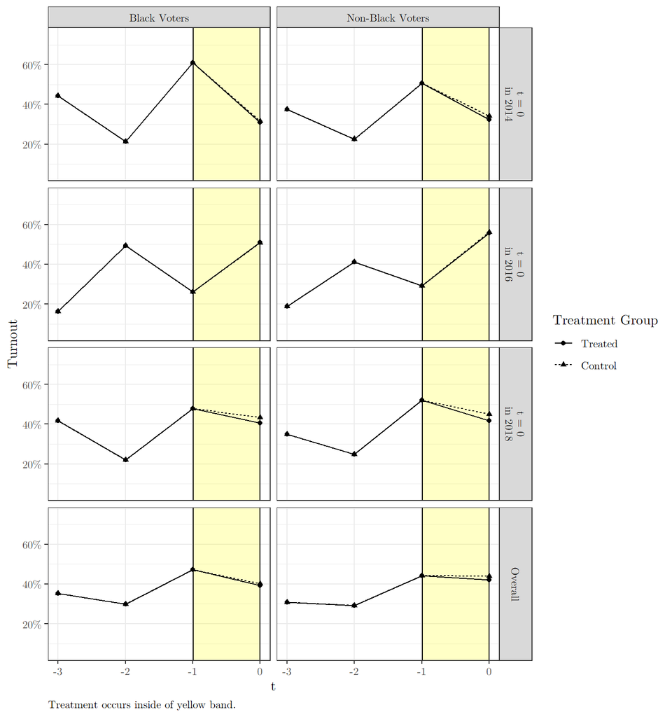

Effect of Being Ticketed on Turnout

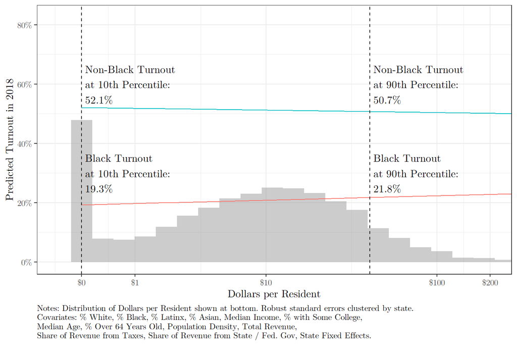

Predicted Turnout, 2018

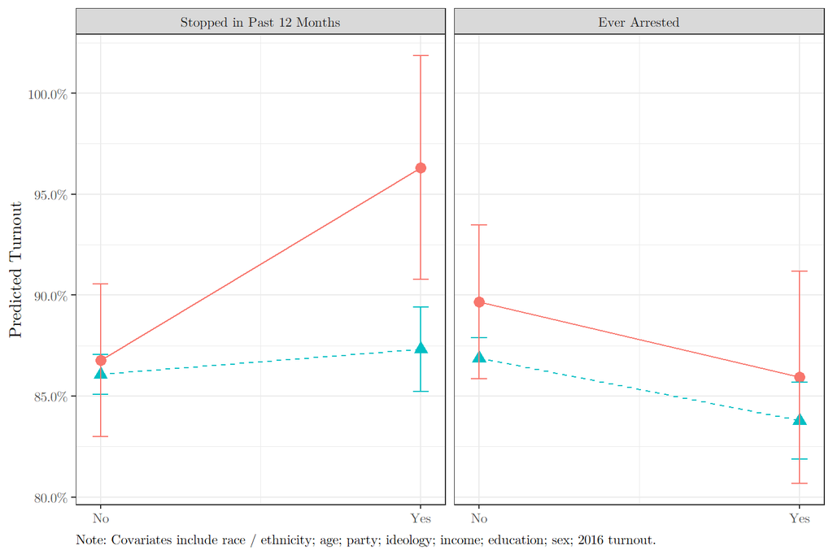

Predicted Turnout, 2020

[^1]: PhD Student, Columbia University, Department of Sociology (jb4487@columbia.edu)
[^2]: PhD Student, CUNY Graduate Center, Department of Sociology (kmorris@gradcenter.cuny.edu)